# IODS course project

Petteri Karsisto

# Introduction to Open Data Science - Course Project

# About the project

Hello world! This is my first entry to the [Introduction to Open Data Science 2020](https://mooc.helsinki.fi/course/view.php?id=385) course project. This course teaches data analysis using R and writing stuff down with R Markdown. Interesting and useful stuff. Previously I’ve worked with Python and GitHub-flavored Markdown syntax.

I hope to learn more of the “statistics” side in data science. Topics such as

- How to ensure my analysis is statistically sound?
- How to process the data “properly” (outlier detection etc)?
- How to select proper methods and descriptive “output numbers”?
- How to discern independent and co-dependent parameters from the data.

By the way, here is the link to my [GitHub repository](https://github.com/pkars/IODS-project) for this project. Currently it’s rather empty as the “real” work starts next week…

Back to top.

# Regression and model validation

This section is the report for the second week of IODS. To start with, here are the instructions given for writing this report:

> *Describe the work you have done this week and summarize your learning.*
> - Describe your work and results clearly.
> - Assume the reader has an introductory course level understanding of writing and reading R code as well as statistical methods.
> - Assume the reader has no previous knowledge of your data or the more advanced methods you are using.

With that out of the way, let’s start the analysis part of the current exercise set!

## Setting up

First, I need to include a couple of libraries to properly build (or rather, “knit”) this report.

```r
# knitr is used to build this report, so it is included by default

# Remove the '##' from each line of R output blocks
knitr::opts_chunk$set(comment = '')

# Libraries for convenience
library(dplyr)
library(ggplot2)
library(GGally)
library(gridExtra)

# NOTE: Messages are omitted
```

## The analysis data

The analysis data was produced in “Data wrangling” part of the exercises. The original data is the “JYTOPKYS2” study data by Kimmo Vehkalahti. The original data is available from [here](https://www.mv.helsinki.fi/home/kvehkala/JYTmooc/JYTOPKYS3-data.txt) and the data is explained [here](https://www.mv.helsinki.fi/home/kvehkala/JYTmooc/JYTOPKYS2-meta.txt).

The analysis data is a mix of original variables (`gender`, `age`, `attitude`, and `points`) and derived variables (`deep`, `stra`, and `surf`). The original and derived variables are explained as following, based on Vehkalahti’s metadata. Note that the derived variables were omitted from the original data linked above – so that we’d have to calculate them ourselves – but they were included in the metadata.

| Variable | Meaning | Type | Notes |
| --- | --- | --- | --- |
| `gender` | Gender of the student | Categorical | “M” or “F” |
| `age` | Age (in years) | Number | derived from the date of birth |
| `attitude` | Global attitude toward statistics | Number | Sum of 10 answers |
| `points` | Total points from coursework | Number | Student’s best exam score + extra points from answering the study questionnaire |
| `deep` | Average score of answers related to Deep approach | Number | Avg. of 12 answers |
| `stra` | Average score of answers related to Strategic approach | Number | Avg. of 12 answers |
| `surf` | Average score of answers related to Surface approach | Number | Avg. of 8 answers |

You can see the creation script [here](https://github.com/pkars/IODS-project/blob/master/data/create_learning2014.R) (most recent version) or the original from [commit `bb6de84`](https://github.com/pkars/IODS-project/blob/bb6de848b26bd4fbd3e909cce19831c8d86ccbee/data/create_learning2014.R)). The script stores the data to `learning2014.csv`, so let’s start by reading that file and printing out the dataset structure, first few rows[^1], and some summary statistics.

```r
dset <- read.csv("data/learning2014.csv")
```

```r
str(dset)
```

```
'data.frame':   166 obs. of  7 variables:
 $ gender  : chr  "F" "M" "F" "M" ...
 $ age     : int  53 55 49 53 49 38 50 37 37 42 ...
 $ attitude: int  37 31 25 35 37 38 35 29 38 21 ...
 $ deep    : num  3.58 2.92 3.5 3.5 3.67 ...
 $ stra    : num  3.38 2.75 3.62 3.12 3.62 ...
 $ surf    : num  2.58 3.17 2.25 2.25 2.83 ...
 $ points  : int  25 12 24 10 22 21 21 31 24 26 ...
```

```r
knitr::kable(head(dset, 5))  # Prettier table, see also footnote
```

| gender | age | attitude | deep | stra | surf | points |
| --- | --- | --- | --- | --- | --- | --- |
| F | 53 | 37 | 3.583333 | 3.375 | 2.583333 | 25 |
| M | 55 | 31 | 2.916667 | 2.750 | 3.166667 | 12 |
| F | 49 | 25 | 3.500000 | 3.625 | 2.250000 | 24 |
| M | 53 | 35 | 3.500000 | 3.125 | 2.250000 | 10 |
| M | 49 | 37 | 3.666667 | 3.625 | 2.833333 | 22 |

```r
summary(dset)
```

```
    gender               age           attitude          deep
 Length:166         Min.   :17.00   Min.   :14.00   Min.   :1.583
 Class :character   1st Qu.:21.00   1st Qu.:26.00   1st Qu.:3.333
 Mode  :character   Median :22.00   Median :32.00   Median :3.667
                    Mean   :25.51   Mean   :31.43   Mean   :3.680
                    3rd Qu.:27.00   3rd Qu.:37.00   3rd Qu.:4.083
                    Max.   :55.00   Max.   :50.00   Max.   :4.917
      stra            surf           points
 Min.   :1.250   Min.   :1.583   Min.   : 7.00
 1st Qu.:2.625   1st Qu.:2.417   1st Qu.:19.00
 Median :3.188   Median :2.833   Median :23.00
 Mean   :3.121   Mean   :2.787   Mean   :22.72
 3rd Qu.:3.625   3rd Qu.:3.167   3rd Qu.:27.75
 Max.   :5.000   Max.   :4.333   Max.   :33.00
```

```r
count(dset, gender)
```

```
  gender   n
1      F 110
2      M  56
```

This data contains 166 data points (rows). The original data has 187 rows, however the students with 0 points were omitted during the data wrangling. Out of the 166 remaining students, 110 were female and 56 were male. The students’ age ranges from 17 to 55 years, with median at 22 years.

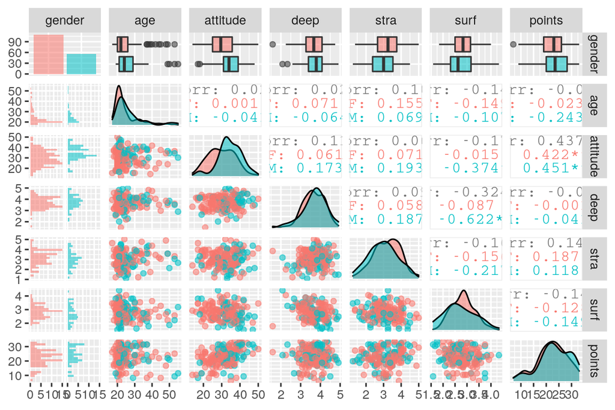

```r
ggpairs(dset,
        mapping = aes(col = gender, alpha = 0.3),
        lower = list(combo=wrap("facethist", bins=20))
       )
```

```r
cor(dset[-1])  # Exclude 'gender' column
```

```
                 age    attitude        deep        stra       surf      points
age       1.00000000  0.02220071  0.02507804  0.10244409 -0.1414052 -0.09319032
attitude  0.02220071  1.00000000  0.11024302  0.06174177 -0.1755422  0.43652453
deep      0.02507804  0.11024302  1.00000000  0.09650255 -0.3238020 -0.01014849
stra      0.10244409  0.06174177  0.09650255  1.00000000 -0.1609729  0.14612247
surf     -0.14140516 -0.17554218 -0.32380198 -0.16097287  1.0000000 -0.14435642
points   -0.09319032  0.43652453 -0.01014849  0.14612247 -0.1443564  1.00000000
```

## Fitting the linear model

Next up is a task to fit a linear model to the data, where `points` is the target variable and one or more other variables are the explanatory variables. First instruction was to select three explanatory variables. I chose `attitude`, `stra`, and `surf` as their correlation coefficients with `points` were the largest (absolute value). And the results are…

```r
# Target: points
# Explanatory variables (3): attitude, stra, surf
#   based on absolute value of correlation coefficient (Pearson)
model <- lm(points ~ attitude + stra + surf, dset)
summary(model)
```

```
Call:
lm(formula = points ~ attitude + stra + surf, data = dset)

Residuals:
     Min       1Q   Median       3Q      Max
-17.1550  -3.4346   0.5156   3.6401  10.8952

Coefficients:
            Estimate Std. Error t value Pr(>|t|)
(Intercept) 11.01711    3.68375   2.991  0.00322 **
attitude     0.33952    0.05741   5.913 1.93e-08 ***
stra         0.85313    0.54159   1.575  0.11716
surf        -0.58607    0.80138  -0.731  0.46563
---
Signif. codes:  0 '***' 0.001 '**' 0.01 '*' 0.05 '.' 0.1 ' ' 1

Residual standard error: 5.296 on 162 degrees of freedom
Multiple R-squared:  0.2074,    Adjusted R-squared:  0.1927
F-statistic: 14.13 on 3 and 162 DF,  p-value: 3.156e-08
```

Yeah, not so good. First, I’ll have to quickly interpret the output. First is the distribution of residuals. A (minimum) residual of “-17” seems rather large (it’s absolute value, that is), when the points range from 7 to 33 – there might be some strong outliers. At least median is close to zero, which is reassuring. Next are the coefficients for the linear regression. The `estimate` column shows the slope of the linear regression (except for the intercept it shows the value of “target” when all explanatory variables are zero). So having zero attitude and learning strategies you’d expect a student to get 11 points. For the slopes, the value means “the increase or decrease in points, when attitude/strategic learning/surface learning value increases by one unit”. So, having larger `attitude` and `stra` scores would indicate better performance, whereas larger `surf` score would decrease performance. Next column, `Std. Error`, shows the standard error of the estimate. Third column, `t value`, shows the t-statistic – which is a measure of the estimates statistical significance. However that value is rather transient by itself, so we’ll rely on the fourth column to interpret the t-statistic. This column shows the *probability of having this particular non-zero value for estimate by random chance*, or in other words, how confident we can be in rejecting the null hypothesis. One more time for the non-statisticians like me: the smaller p-value is, the more we can trust that our target and explanatory variable have a relationship – i.e. the slope is not zero. Other interesting numbers are the R-squared values: they estimate “the fraction of variance explained by the model”. Zero means that our model cannot explain anything about the target variable, while one would mean that our model explains everything, including any random errors.

So, looking at the significance of the estimates, it looks like that only the `attitude` has any explaining power here. But `stra` is close. The R<sup>2</sup> values indicate that we’re not capturing the majority of the variance with this model – or that our data is really noisy and has plenty of unknown random errors. Let’s try to improve the model by dropping `surf` as it is not meaningful at all; maybe it masks `stra` a little.

```r
model <- lm(points ~ attitude + stra, dset)
summary(model)
```

```
Call:
lm(formula = points ~ attitude + stra, data = dset)

Residuals:
     Min       1Q   Median       3Q      Max
-17.6436  -3.3113   0.5575   3.7928  10.9295

Coefficients:
            Estimate Std. Error t value Pr(>|t|)
(Intercept)  8.97290    2.39591   3.745  0.00025 ***
attitude     0.34658    0.05652   6.132 6.31e-09 ***
stra         0.91365    0.53447   1.709  0.08927 .
---
Signif. codes:  0 '***' 0.001 '**' 0.01 '*' 0.05 '.' 0.1 ' ' 1

Residual standard error: 5.289 on 163 degrees of freedom
Multiple R-squared:  0.2048,    Adjusted R-squared:  0.1951
F-statistic: 20.99 on 2 and 163 DF,  p-value: 7.734e-09
```

Well, there is a slight improvement for `stra`. Also, the intercept got more significant! Cool. Also, adjusted R<sup>2</sup> slightly improved. However, the `stra` is still a little suspect whether it truly has some explaining power. Let’s inspect it a little further by *plotting* the scatterplots for `points ~ attitude` and `points ~ stra`:

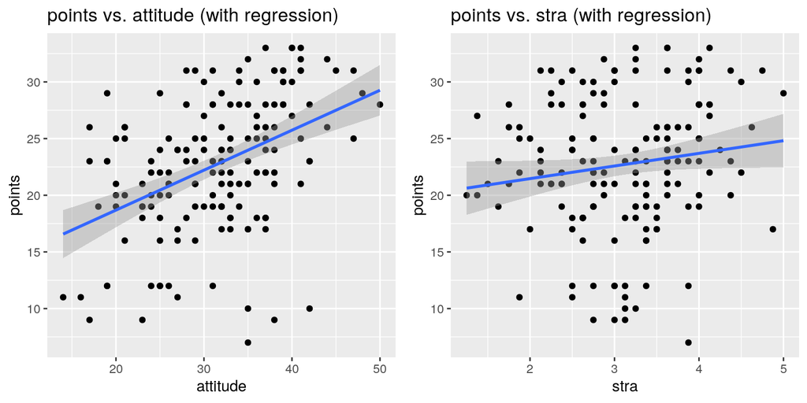

```r
# Do scatterplots with ggplot2: prettier figures and include a linear regression fit easily!
p_att <- ggplot(dset, mapping=aes(attitude, points)) +         # Set up the figure
           geom_point() +                                      # Add scatter points
           geom_smooth(method="lm") +                          # Add linear regression with confidence interval
           labs(title="points vs. attitude (with regression)") # Add title for the plot

p_stra <- ggplot(dset, mapping=aes(stra, points)) +
            geom_point() +
            geom_smooth(method="lm") +
            labs(title="points vs. stra (with regression)")

# Use gridExtra package to present the figures side-by-side. Saves some screen space :)
grid.arrange(p_att, p_stra, nrow=1, ncol=2)
```

Okay, so, the left and right figures have `attitude` and `stra` respectively as explanatory variable. As expected, `attitude` shows at least some linear pattern in the scatter plot. Though there are some points rather far away from the regression line (I’ll explore this in a bit)… On the contrary, `stra` plot doesn’t seem to have any discernible pattern, and the regression line’s slope is quite close to zero. So I’m not convinced that `stra` would be a good explanatory variable here. Let’s see what happens when I drop `stra` also…

```r
model <- lm(points ~ attitude, dset)
summary(model)
```

```
Call:
lm(formula = points ~ attitude, data = dset)

Residuals:
     Min       1Q   Median       3Q      Max
-16.9763  -3.2119   0.4339   4.1534  10.6645

Coefficients:
            Estimate Std. Error t value Pr(>|t|)
(Intercept) 11.63715    1.83035   6.358 1.95e-09 ***
attitude     0.35255    0.05674   6.214 4.12e-09 ***
---
Signif. codes:  0 '***' 0.001 '**' 0.01 '*' 0.05 '.' 0.1 ' ' 1

Residual standard error: 5.32 on 164 degrees of freedom
Multiple R-squared:  0.1906,    Adjusted R-squared:  0.1856
F-statistic: 38.61 on 1 and 164 DF,  p-value: 4.119e-09
```

Yes, there is some change. Most drastic change is in intercept’s significance: the t-value nearly doubled and the corresponding probability value became five magnitudes smaller. Also, the residuals minimum, maximum, and median got all a little closer to zero. Although both multiple and adjusted R<sup>2</sup> value took a minor hit (they weren’t very high to begin with, though). Speaking of R<sup>2</sup> values being low, looks like our simple linear model explains only about 19% of the variance. That might be acceptable for this study, but I’d be cautious to use this model in forecasting. Regardless, it shows that there is a relationship between the two variables.

## Interpreting the model and the model diagnostics

So, based on the above analysis, the student’s attitude towards statistics can indicate their course performance: more enthusiastic student is likely to perform better than a student who is not very interested in statistics. However, having a good attitude towards statistics won’t guarantee them success! There must be something else, as the scatter plot for `points ~ attitude` hints: the points are rather spread out from the regression line.

To conclude the analysis, I’ll study the model’s diagnostics a bit. A good data science practice calls for critical evaluation of the model – you shouldn’t blindly trust a model output without knowing if the model is reliable and trustworthy. In linear regression, we implicitly assume a couple of things about our random errors:

1. The errors are normally distributed
2. The error distribution has a zero mean and a constant variance
3. The errors are not correlated with each other

For checking the validity of these assumptions, the figure below shows two diagnostics plots: Residuals vs. Fitted and Normal Q-Q plot. The first one should have no visible pattern if the assumptions are true. Well, that doesn’t seem to be the case here. The residuals seem to converge towards zero when fitted value increases. That indicates that the variance of errors is not constant, violating the second point listed above. The Q-Q plot shows how well the residual distribution matches an idealised (theoretical) normal distribution. The points on the figure should be close to a straight line – for two identical distributions the points would all be on the dotted line in the figure. If the points deviate from the line, then the normal distribution assumption doesn’t hold. In the picture, there is a slight curve on the points, and the outernmost quantiles clearly deviate from the ideal line. So, the normality assumption is violated at the edges of the distribution – at the center the distribution is almost “normal”.

Then, there is a question of outliers, which are data points that deviate from the main body of data points. Does our data have outliers, that will distort the fitting process by having strong “leverage”? The third plot, “Residuals vs Leverage” answers this question. As the leverages are quite small (<0.05), there doesn’t seem to be any data points that would affect our fit disproportionately. Turns out the data points with large residuals were close to the centerpoint of the linear fit, so they didn’t have that much leverage.

In conclusion, the model can indicate something about the relationship between the students’ performance and their attitude towards statistics, but the model is not very good for prediction purposes. A linear regression model is not suitable for this data – an approach with less assumptions about the random errors is required.

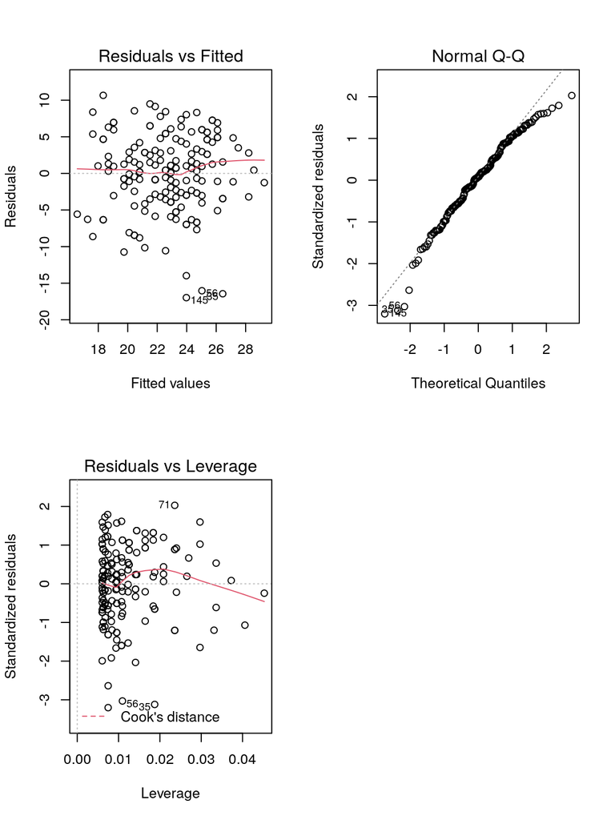

```r
par(mfrow = c(2,2))
plot(model, which=c(1,2,5))
```

Back to top.

# Logistic regression

A new week, a new report! First, I need to set up the libraries and knitr options.

```r
# knitr options: No "##" before output
library(dplyr)
library(ggplot2)
library(GGally)
library(gridExtra)
library(tidyr)
library(reshape2)
```

## Data

Today’s data is from UCI Machine Learning Repository, kindly provided by Paulo Cortez. The data is [Student Performance Data Set](https://archive.ics.uci.edu/ml/datasets/Student+Performance) (Cortez and Silva, 2008). The authors describe the dataset as following:

*“This data approach student achievement in secondary education of two Portuguese schools. The data attributes include student grades, demographic, social and school related features) and it was collected by using school reports and questionnaires. Two datasets are provided regarding the performance in two distinct subjects: Mathematics (mat) and Portuguese language (por). In [Cortez and Silva, 2008], the two datasets were modeled under binary/five-level classification and regression tasks. Important note: the target attribute G3 has a strong correlation with attributes G2 and G1. This occurs because G3 is the final year grade (issued at the 3rd period), while G1 and G2 correspond to the 1st and 2nd period grades. It is more difficult to predict G3 without G2 and G1, but such prediction is much more useful (see paper source for more details).”*

However, I’ve modified the data as following (see the R script [here](https://github.com/pkars/IODS-project/blob/master/data/create_alc.R)):

- Join the two datasets using 13 identifying variables: `"school", "sex", "age", "address", "famsize", "Pstatus", "Medu", "Fedu", "Mjob", "Fjob", "reason", "nursery", "internet"`
- For each column that was not used in joining and appeared in both datasets, combine them into one by taking the average value (numerical values) or the value in the first column (categorical values).
- Calculate average alcohol use (column `alc_use`) by calculating the mean of weekday and weekend alcohol use values.
- Create a logical column `high_use` where `TRUE` denotes the students who have average alcohol use value greater than 2.

Here are the variables and their explanations (adapted from the data source website):,

| Variable | Meaning | Datatype | Type | Notes |
| --- | --- | --- | --- | --- |
| school | student’s school | Categorical | *Identifier* | ‘GP’ - Gabriel Pereira or ‘MS’ - Mousinho da Silveira |
| sex | student’s sex | Categorical | *Identifier* | ‘F’ - female or ‘M’ - male |
| age | student’s age | Numeric | *Identifier* | from 15 to 22 |
| address | student’s home address type | Categorical | *Identifier* | ‘U’ - urban or ‘R’ - rural |
| famsize | family size | Categorical | *Identifier* | ‘LE3’ - less or equal to 3 or ‘GT3’ - greater than 3 |
| Pstatus | parent’s cohabitation status | Categorical | *Identifier* | ‘T’ - living together or ‘A’ - apart |
| Medu | mother’s education | Categorical | *Identifier* | 0 - none, 1 - primary education (4th grade), 2 - 5th to 9th grade, 3 - secondary education or 4 - higher education |
| Fedu | father’s education | Categorical | *Identifier* | 0 - none, 1 - primary education (4th grade), 2 - 5th to 9th grade, 3 - secondary education or 4 - higher education |
| Mjob | mother’s job | Categorical | *Identifier* | ‘teacher’, ‘health’ care related, civil ‘services’ (e.g. administrative or police), ‘at_home’ or ‘other’ |
| Fjob | father’s job | Categorical | *Identifier* | ‘teacher’, ‘health’ care related, civil ‘services’ (e.g. administrative or police), ‘at_home’ or ‘other’ |
| reason | reason to choose this school | Categorical | *Identifier* | close to ‘home’, school ‘reputation’, ‘course’ preference or ‘other’ |
| guardian | student’s guardian | Categorical | Original | ‘mother’, ‘father’ or ‘other’ |
| traveltime | home to school travel time | Categorical | Original | 1 - <15 min., 2 - 15 to 30 min., 3 - 30 min. to 1 hour, or 4 - >1 hour |
| studytime | weekly study time | Categorical | Original | 1 - <2 hours, 2 - 2 to 5 hours, 3 - 5 to 10 hours, or 4 - >10 hours |
| failures | number of past class failures | Categorical | Original | n if 1<=n<3, else 4 |
| schoolsup | extra educational support | Categorical | Original | yes or no |
| famsup | family educational support | Categorical | Original | yes or no |
| paid | extra paid classes within the course subject (Math or Portuguese) | Categorical | Original | yes or no |
| activities | extra-curricular activities | Categorical | Original | yes or no |
| nursery | attended nursery school | Categorical | *Identifier* | yes or no |
| higher | wants to take higher education | Categorical | Original | yes or no |
| internet | Internet access at home | Categorical | *Identifier* | yes or no |
| romantic | with a romantic relationship | Categorical | Original | yes or no |
| famrel | quality of family relationships | Categorical | Original | from 1 - very bad to 5 - excellent |
| freetime | free time after school | Categorical | Original | from 1 - very low to 5 - very high |
| goout | going out with friends | Categorical | Original | from 1 - very low to 5 - very high |
| Dalc | workday alcohol consumption | Categorical | Original | from 1 - very low to 5 - very high |
| Walc | weekend alcohol consumption | Categorical | Original | from 1 - very low to 5 - very high |
| health | current health status | Categorical | Original | from 1 - very bad to 5 - very good |
| absences | number of school absences | Numeric | Original | from 0 to 93 |
| G1 | first period grade | Numeric | Original | from 0 to 20 |
| G2 | second period grade | Numeric | Original | from 0 to 20 |
| G3 | final grade | Numeric | Original | from 0 to 20 |
| alc_use | Average alcohol usage | Numeric | Calculated | Avg. of `Dalc`and `Walc` |
| high_use | Has high alcohol consumption | Boolean | Calculated | `alc_use > 2` |

So, with that out of the way, let’s see the actual data.

```r
dataset <- read.csv("data/alc.csv", header=TRUE)
str(dataset)
```

```
'data.frame':   382 obs. of  35 variables:
 $ school    : chr  "GP" "GP" "GP" "GP" ...
 $ sex       : chr  "F" "F" "F" "F" ...
 $ age       : int  15 15 15 15 15 15 15 15 15 15 ...
 $ address   : chr  "R" "R" "R" "R" ...
 $ famsize   : chr  "GT3" "GT3" "GT3" "GT3" ...
 $ Pstatus   : chr  "T" "T" "T" "T" ...
 $ Medu      : int  1 1 2 2 3 3 3 2 3 3 ...
 $ Fedu      : int  1 1 2 4 3 4 4 2 1 3 ...
 $ Mjob      : chr  "at_home" "other" "at_home" "services" ...
 $ Fjob      : chr  "other" "other" "other" "health" ...
 $ reason    : chr  "home" "reputation" "reputation" "course" ...
 $ nursery   : chr  "yes" "no" "yes" "yes" ...
 $ internet  : chr  "yes" "yes" "no" "yes" ...
 $ guardian  : chr  "mother" "mother" "mother" "mother" ...
```

[output cut: 21 more lines]

This time I’ve omitted showing `head`, as the table is *pretty wide*. However, the dataframe summary shows the first values from each column, so that’ll do. Most of the variables are categorical data - although the authors have used integers to denote some of the classes.

## Research question(s)

Next, I’ll explore four variables (`absences`, `health`, `freetime`, `famrel`) and their relationship with high or low alcohol consumption. My initial hypothesis would be that high value for `absences` corresponds to high alcohol usage (`high_use=TRUE`) whereas for `health` and `famrel` the higher values indicate low alcohol consumption. I suspect that the `freetime` variable might not have any discernible relationship with alcohol usage, as it measures the amount of free time, not how the student spends the time. A lot of free time only increases the number of opportunities to drink alcohol, which may or may not lead to actual consumption.

```r
# Attach a ID number for each row and select only the columns-of-interest
data <- mutate(dataset, ID = row_number()) %>%
  select(any_of(c("ID", "high_use", "absences", "health", "freetime", "famrel")))
# Let's see...
summary(data[-1])  # Ignore ID
```

```
  high_use          absences        health         freetime        famrel
 Mode :logical   Min.   : 0.0   Min.   :1.000   Min.   :1.00   Min.   :1.000
 FALSE:268       1st Qu.: 1.0   1st Qu.:3.000   1st Qu.:3.00   1st Qu.:4.000
 TRUE :114       Median : 3.0   Median :4.000   Median :3.00   Median :4.000
                 Mean   : 4.5   Mean   :3.573   Mean   :3.22   Mean   :3.937
                 3rd Qu.: 6.0   3rd Qu.:5.000   3rd Qu.:4.00   3rd Qu.:5.000
                 Max.   :45.0   Max.   :5.000   Max.   :5.00   Max.   :5.000
```

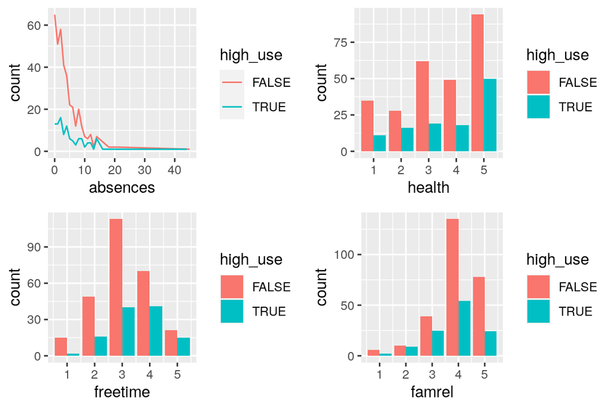

```r
# Plot with ggplot2, line chart for absences and bar charts for others
p1 <- ggplot(data, aes(absences)) + stat_count(geom="line", aes(colour=high_use) )
p2 <- ggplot(data, aes(health)) + geom_bar(aes(fill=high_use), position="dodge")
p3 <- ggplot(data, aes(freetime)) + geom_bar(aes(fill=high_use), position="dodge")
p4 <- ggplot(data, aes(famrel)) + geom_bar(aes(fill=high_use), position="dodge")

# Use gridExtra package to present the figures side-by-side. Saves some screen space :)
grid.arrange(p1, p2, p3, p4, nrow=2, ncol=2)
```

Well, guess I was wrong. `freetime` seems to have the clearest signal, as the peaks are at 3 for `high_use=FALSE` and at 4 for `high_use=TRUE`. For other plots, it’s kinda hard to see any signal. Probably this kind of visual inspection isn’t the best tool here. Let’s print out some numbers.

```r
table(high_use = data$high_use, absences = cut(data$absences, include.lowest=T, breaks=c(0,1,5,10,15,20,30)))%>% proportions() %>% round(digits=3) %>% addmargins
```

```
        absences
high_use [0,1] (1,5] (5,10] (10,15] (15,20] (20,30]   Sum
   FALSE 0.237 0.303  0.132   0.021   0.008   0.003 0.704
   TRUE  0.068 0.111  0.058   0.039   0.011   0.011 0.298
   Sum   0.305 0.414  0.190   0.060   0.019   0.014 1.002
```

```r
table(high_use = data$high_use, health = data$health)%>% proportions() %>% round(digits=3) %>% addmargins
```

```
        health
high_use     1     2     3     4     5   Sum
   FALSE 0.092 0.073 0.162 0.128 0.246 0.701
   TRUE  0.029 0.042 0.050 0.047 0.131 0.299
   Sum   0.121 0.115 0.212 0.175 0.377 1.000
```

```r
table(high_use = data$high_use, freetime = data$freetime)%>% proportions() %>% round(digits=3) %>% addmargins
```

```
        freetime
high_use     1     2     3     4     5   Sum
   FALSE 0.039 0.128 0.296 0.183 0.055 0.701
   TRUE  0.005 0.042 0.105 0.107 0.039 0.298
   Sum   0.044 0.170 0.401 0.290 0.094 0.999
```

```r
table(high_use = data$high_use, famrel = data$famrel) %>% proportions() %>% round(digits=3) %>% addmargins
```

```
        famrel
high_use     1     2     3     4     5   Sum
   FALSE 0.016 0.026 0.102 0.353 0.204 0.701
   TRUE  0.005 0.024 0.065 0.141 0.063 0.298
   Sum   0.021 0.050 0.167 0.494 0.267 0.999
```

So, for absences it looks like the `FALSE` dominates the ratio at low levels while `TRUE` gets a larger piece of the pie at high values. So I think my hypothesis was correct for that one. For freetime the proportion of `TRUE` increases from lowest to highest class, though it never dominates. I don’t see any clear signal in `health` and `famrel` tables. So, for my hypotheses:

- `absences`: CORRECT
- `health`: inconlusive
- `freetime`: WRONG
- `famrel`: inconclusive

Well, that’s that. The more you know!

## Regression

Moving on to the logistic regression, we’ll see if The Machine has more insight than I have. Probably, as it is *much* better at number-crunching than I am.

```r
# Fit a model!
model <- glm(high_use ~ absences + health + freetime + famrel, data=data, family="binomial")
summary(model)
```

```
Call:
glm(formula = high_use ~ absences + health + freetime + famrel,
    family = "binomial", data = data)

Deviance Residuals:
    Min       1Q   Median       3Q      Max
-2.0084  -0.8216  -0.6462   1.1891   2.0837

Coefficients:
            Estimate Std. Error z value Pr(>|z|)
(Intercept) -1.74200    0.66202  -2.631 0.008505 **
absences     0.08848    0.02235   3.960 7.51e-05 ***
health       0.11100    0.08657   1.282 0.199762
freetime     0.41336    0.12472   3.314 0.000919 ***
famrel      -0.33352    0.12977  -2.570 0.010167 *
---
Signif. codes:  0 '***' 0.001 '**' 0.01 '*' 0.05 '.' 0.1 ' ' 1

(Dispersion parameter for binomial family taken to be 1)

    Null deviance: 465.68  on 381  degrees of freedom
Residual deviance: 430.06  on 377  degrees of freedom
AIC: 440.06

Number of Fisher Scoring iterations: 4
```

So, `absences`, `health` and `freetime` have a positive coefficient and `famrel` a negative. So maybe I got that last one right, after all? Anyways, health is not a significant variable here, so I’ll dump it and play with the remaining three.

```r
# Re-fit without health
model <- glm(high_use ~ absences + freetime + famrel, data=data, family="binomial")
summary(model)
```

```
Call:
glm(formula = high_use ~ absences + freetime + famrel, family = "binomial",
    data = data)

Deviance Residuals:
    Min       1Q   Median       3Q      Max
-1.9318  -0.8233  -0.6580   1.1905   1.9597

Coefficients:
            Estimate Std. Error z value Pr(>|z|)
(Intercept) -1.43379    0.61550  -2.329 0.019835 *
absences     0.08813    0.02236   3.942 8.09e-05 ***
freetime     0.41844    0.12419   3.369 0.000754 ***
famrel      -0.31322    0.12824  -2.443 0.014586 *
---
Signif. codes:  0 '***' 0.001 '**' 0.01 '*' 0.05 '.' 0.1 ' ' 1

(Dispersion parameter for binomial family taken to be 1)

    Null deviance: 465.68  on 381  degrees of freedom
Residual deviance: 431.73  on 378  degrees of freedom
AIC: 439.73

Number of Fisher Scoring iterations: 4
```

```r
# Odds ratio and confidence intervals
OR <- coef(model) %>% exp
CI <- confint(model) %>% exp
cbind(OR,CI) # SHOW IT TO ME!
```

```
                   OR      2.5 %    97.5 %
(Intercept) 0.2384039 0.06958343 0.7831989
absences    1.0921339 1.04749241 1.1438386
freetime    1.5195946 1.19585392 1.9480047
famrel      0.7310919 0.56733732 0.9397040
```

So, the Odds Ratio (OR) is defined as $OR = p / (1 - p)$, where $p = P(Y=1)$, which denotes *probability that our target is `TRUE`*. So when the OR is greater than 1, then our target becomes more likely to be `TRUE` than `FALSE` when our estimator increases in value[^2]. Based on the numbers, increasing number of absences and more free time available correspond to high alcohol consumption, while improving family relations decreases the alcohol consumption. So, let’s revise my hypotheses:

- `absences`: CORRECT
- `health`: inconlusive (statistically not significant)
- `freetime`: WRONG
- `famrel`: CORRECT

## References

P. Cortez and A. Silva. Using Data Mining to Predict Secondary School Student Performance. In A. Brito and J. Teixeira Eds., Proceedings of 5th FUture BUsiness TEChnology Conference (FUBUTEC 2008) pp. 5-12, Porto, Portugal, April, 2008, EUROSIS, ISBN 978-9077381-39-7. [Web Link](http://www3.dsi.uminho.pt/pcortez/student.pdf)

Back to top.

# Clustering and classification

A new week, a new section! This week is about clustering the data. As per usual, here are the libraries I’m using.

```r
# Used knitr options: No "##" before output
library(dplyr)
library(ggplot2)
library(GGally)
library(gridExtra)
library(reshape2)
library(tidyr)
library(MASS)  # Contains the used dataset
library(corrplot)
set.seed(2020)
```

## Data description

Unlike previous weeks, this week we are using a dataset that we have not wrangled with before! The data is the `Boston` dataset that is available in R package called `MASS`. Below is a table that lists the columns in the dataset. Full disclosure, I lifted the descriptions directly from R documentation (accessible by typing `?Boston` in R console).

| Column | Description |
| --- | --- |
| crim | per capita crime rate by town. |
| zn | proportion of residential land zoned for lots over 25,000 sq.ft. |
| indus | proportion of non-retail business acres per town. |
| chas | Charles River dummy variable (= 1 if tract bounds river; 0 otherwise). |
| nox | nitrogen oxides concentration (parts per 10 million). |
| rm | average number of rooms per dwelling. |
| age | proportion of owner-occupied units built prior to 1940. |
| dis | weighted mean of distances to five Boston employment centres. |
| rad | index of accessibility to radial highways. |
| tax | full-value property-tax rate per $10,000. |
| ptratio | pupil-teacher ratio by town. |
| black | *1000(Bk - 0.63)^2* where *Bk* is the proportion of blacks by town. |
| lstat | lower status of the population (percent). |
| medv | median value of owner-occupied homes in $1000s. |

The data is titled as *Housing Values in Suburbs of Boston*. The dataset contains 14 variables and 506 rows. All columns are numerical, although the variable `chas` is actually a boolean indicator represented as ones and zeros. Also as per usual, here are the outputs for `str`, `head` and `summary` functions for the `Boston` dataset:

```r
data("Boston")  # Creates variable named Boston
str(Boston)
```

```
'data.frame':   506 obs. of  14 variables:
 $ crim   : num  0.00632 0.02731 0.02729 0.03237 0.06905 ...
 $ zn     : num  18 0 0 0 0 0 12.5 12.5 12.5 12.5 ...
 $ indus  : num  2.31 7.07 7.07 2.18 2.18 2.18 7.87 7.87 7.87 7.87 ...
 $ chas   : int  0 0 0 0 0 0 0 0 0 0 ...
 $ nox    : num  0.538 0.469 0.469 0.458 0.458 0.458 0.524 0.524 0.524 0.524 ...
 $ rm     : num  6.58 6.42 7.18 7 7.15 ...
 $ age    : num  65.2 78.9 61.1 45.8 54.2 58.7 66.6 96.1 100 85.9 ...
 $ dis    : num  4.09 4.97 4.97 6.06 6.06 ...
 $ rad    : int  1 2 2 3 3 3 5 5 5 5 ...
 $ tax    : num  296 242 242 222 222 222 311 311 311 311 ...
 $ ptratio: num  15.3 17.8 17.8 18.7 18.7 18.7 15.2 15.2 15.2 15.2 ...
 $ black  : num  397 397 393 395 397 ...
 $ lstat  : num  4.98 9.14 4.03 2.94 5.33 ...
 $ medv   : num  24 21.6 34.7 33.4 36.2 28.7 22.9 27.1 16.5 18.9 ...
```

```r
knitr::kable(head(Boston, 5))
```

| crim | zn | indus | chas | nox | rm | age | dis | rad | tax | ptratio | black | lstat | medv |
| --- | --- | --- | --- | --- | --- | --- | --- | --- | --- | --- | --- | --- | --- |
| 0.00632 | 18 | 2.31 | 0 | 0.538 | 6.575 | 65.2 | 4.0900 | 1 | 296 | 15.3 | 396.90 | 4.98 | 24.0 |
| 0.02731 | 0 | 7.07 | 0 | 0.469 | 6.421 | 78.9 | 4.9671 | 2 | 242 | 17.8 | 396.90 | 9.14 | 21.6 |
| 0.02729 | 0 | 7.07 | 0 | 0.469 | 7.185 | 61.1 | 4.9671 | 2 | 242 | 17.8 | 392.83 | 4.03 | 34.7 |
| 0.03237 | 0 | 2.18 | 0 | 0.458 | 6.998 | 45.8 | 6.0622 | 3 | 222 | 18.7 | 394.63 | 2.94 | 33.4 |
| 0.06905 | 0 | 2.18 | 0 | 0.458 | 7.147 | 54.2 | 6.0622 | 3 | 222 | 18.7 | 396.90 | 5.33 | 36.2 |

```r
summary(Boston)
```

```
      crim                zn             indus            chas
 Min.   : 0.00632   Min.   :  0.00   Min.   : 0.46   Min.   :0.00000
 1st Qu.: 0.08205   1st Qu.:  0.00   1st Qu.: 5.19   1st Qu.:0.00000
 Median : 0.25651   Median :  0.00   Median : 9.69   Median :0.00000
 Mean   : 3.61352   Mean   : 11.36   Mean   :11.14   Mean   :0.06917
 3rd Qu.: 3.67708   3rd Qu.: 12.50   3rd Qu.:18.10   3rd Qu.:0.00000
 Max.   :88.97620   Max.   :100.00   Max.   :27.74   Max.   :1.00000
      nox               rm             age              dis
 Min.   :0.3850   Min.   :3.561   Min.   :  2.90   Min.   : 1.130
 1st Qu.:0.4490   1st Qu.:5.886   1st Qu.: 45.02   1st Qu.: 2.100
 Median :0.5380   Median :6.208   Median : 77.50   Median : 3.207
 Mean   :0.5547   Mean   :6.285   Mean   : 68.57   Mean   : 3.795
 3rd Qu.:0.6240   3rd Qu.:6.623   3rd Qu.: 94.08   3rd Qu.: 5.188
 Max.   :0.8710   Max.   :8.780   Max.   :100.00   Max.   :12.127
      rad              tax           ptratio          black
 Min.   : 1.000   Min.   :187.0   Min.   :12.60   Min.   :  0.32
 1st Qu.: 4.000   1st Qu.:279.0   1st Qu.:17.40   1st Qu.:375.38
 Median : 5.000   Median :330.0   Median :19.05   Median :391.44
 Mean   : 9.549   Mean   :408.2   Mean   :18.46   Mean   :356.67
 3rd Qu.:24.000   3rd Qu.:666.0   3rd Qu.:20.20   3rd Qu.:396.23
 Max.   :24.000   Max.   :711.0   Max.   :22.00   Max.   :396.90
     lstat            medv
 Min.   : 1.73   Min.   : 5.00
 1st Qu.: 6.95   1st Qu.:17.02
 Median :11.36   Median :21.20
 Mean   :12.65   Mean   :22.53
 3rd Qu.:16.95   3rd Qu.:25.00
 Max.   :37.97   Max.   :50.00
```

Looking at the summary, there are a couple of notable elements visible. First, the `crim` (*per capita crime rate by town*) variable is under 4 for most of the rows, but the maximum is *88.98*, almost three magnitudes larger than the median value (0.26)! The high discrepancy could be explained by the town in question having a low number of people, however the data doesn’t include this value. The variable `zn` (*proportion of residential land zoned for lots over 25000 sq.ft.*) exhibits similar behavior: minimum and median values are both 0 and maximum value is 100. This tells that most of the towns have no residential lots over 25000 sq.ft. in size. Similarly for variable `chas`, which simply denotes which areas are connected to Charles River and which not. Data states that at least 75% of the data is not connected to the river. For drawing more insight from the rest of the data, let’s plot a couple of pictures.

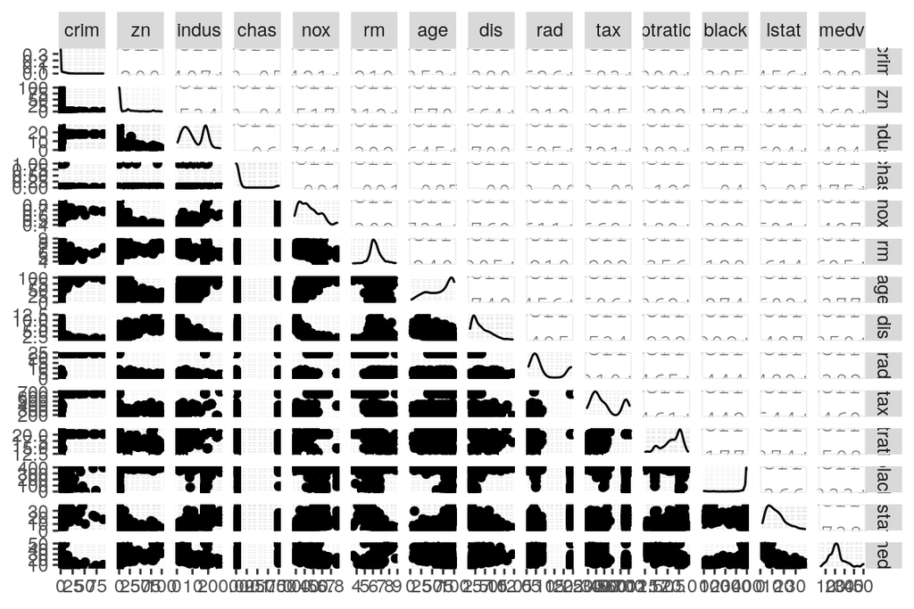

```r
ggpairs(Boston)
```

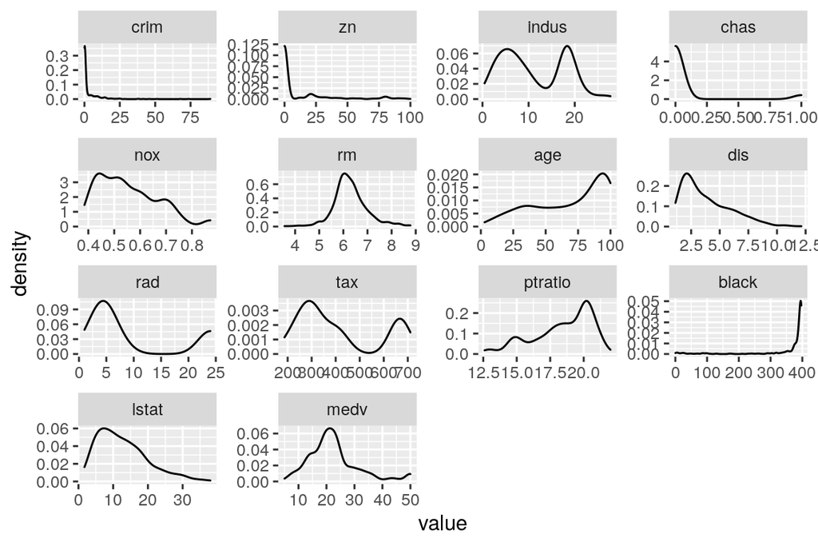

```r
longtable <- melt(Boston)
ggplot(longtable, aes(value)) + geom_density() + facet_wrap(~variable, scales="free")
```

Interestingly, the variable `black` looks like a mirrored version of `crim`. It’s a derived value related to the proportion of black people. I don’t know how the original dataset authors derived the function ($1000\left(Bk - 0.63\right)^2$), but the density graph shows that most of the towns have a proportion of black people that deviates from value 0.63. Plotting the function shows that when its value is over 375.38 (i.e. 1st quantile), the proportion of black people is under 0.02.

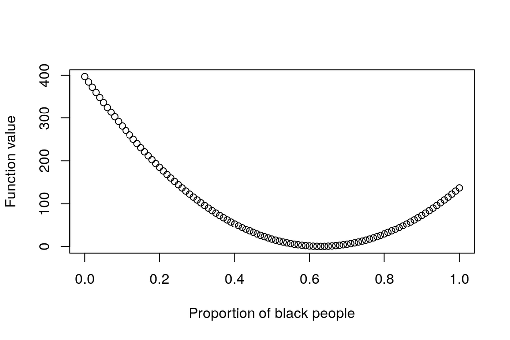

```r
x <- 0:100 / 100
y <- 1000*(x-0.63)^2
plot(x,y, xlab="Proportion of black people", ylab="Function value")
```

```r
# Show the values of x when y > 375.38 (i.e. the value of 1st quantile)
x[y > 375.38]
```

```
[1] 0.00 0.01
```

Finally, let’s plot the correlation between all variables using the fancy `corrplot` function from the `corrplot` library. From the picture, looks like `rad` and `tax` are strongly correlated (positive). That implies that the towns closer to more highways also tax their people more. Other notable correlations are `indus`, `nox` and `age` each negatively correlating with `dis`, and `lstat` correlating with `medv` negatively. Notably, the further away from an employment hotspot the town is, the less there is industrial activity and less pollution (indicated by amount of NO_x_) there is.

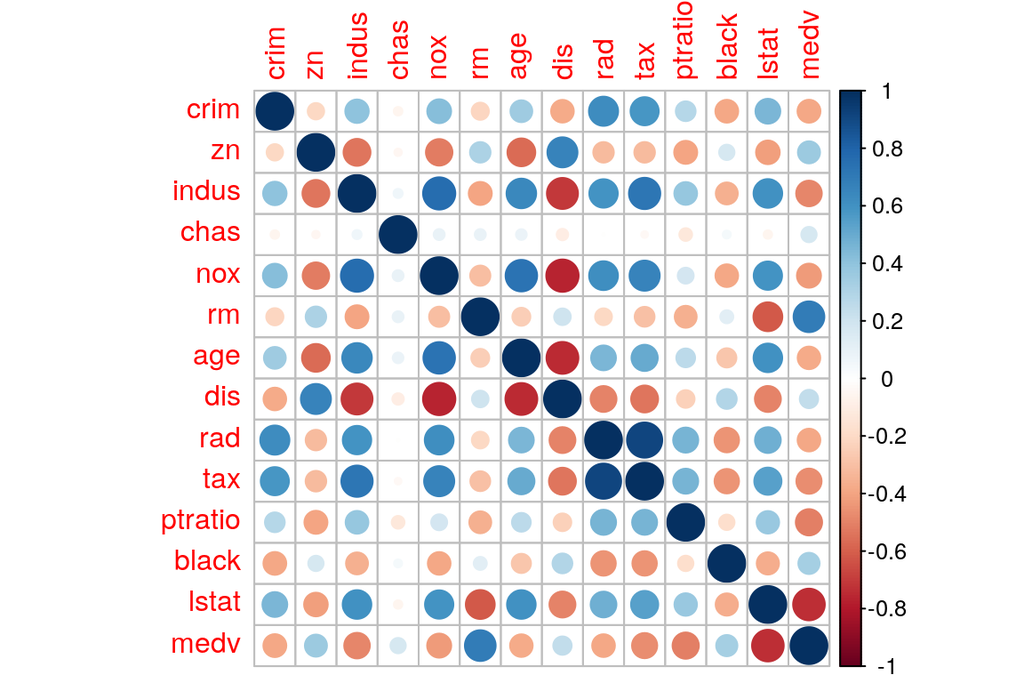

```r
corrplot(cor(Boston), method="circle")
```

## Data wrangling

Whew, that was a lot of text for simply exploring the data! Now I have to actually do something with it, so let’s get to it! First, the data needs to be standardized, which is done by subtracting the mean from the values and dividing by the standard deviation for each column. Now the data has a mean value of zero for each column! Also, the values are now “how many standard deviations away they are from the mean value” instead of actual values. However, the density functions’ form *did not* change, which is also what we want.

```r
scaled <- scale(Boston)

# scale() returns a matrix object, change it to a data.frame
scaled <- as.data.frame(scaled)
summary(scaled)
```

```
      crim                 zn               indus              chas
 Min.   :-0.419367   Min.   :-0.48724   Min.   :-1.5563   Min.   :-0.2723
 1st Qu.:-0.410563   1st Qu.:-0.48724   1st Qu.:-0.8668   1st Qu.:-0.2723
 Median :-0.390280   Median :-0.48724   Median :-0.2109   Median :-0.2723
 Mean   : 0.000000   Mean   : 0.00000   Mean   : 0.0000   Mean   : 0.0000
 3rd Qu.: 0.007389   3rd Qu.: 0.04872   3rd Qu.: 1.0150   3rd Qu.:-0.2723
 Max.   : 9.924110   Max.   : 3.80047   Max.   : 2.4202   Max.   : 3.6648
      nox                rm               age               dis
 Min.   :-1.4644   Min.   :-3.8764   Min.   :-2.3331   Min.   :-1.2658
 1st Qu.:-0.9121   1st Qu.:-0.5681   1st Qu.:-0.8366   1st Qu.:-0.8049
 Median :-0.1441   Median :-0.1084   Median : 0.3171   Median :-0.2790
 Mean   : 0.0000   Mean   : 0.0000   Mean   : 0.0000   Mean   : 0.0000
 3rd Qu.: 0.5981   3rd Qu.: 0.4823   3rd Qu.: 0.9059   3rd Qu.: 0.6617
 Max.   : 2.7296   Max.   : 3.5515   Max.   : 1.1164   Max.   : 3.9566
      rad               tax             ptratio            black
 Min.   :-0.9819   Min.   :-1.3127   Min.   :-2.7047   Min.   :-3.9033
 1st Qu.:-0.6373   1st Qu.:-0.7668   1st Qu.:-0.4876   1st Qu.: 0.2049
 Median :-0.5225   Median :-0.4642   Median : 0.2746   Median : 0.3808
 Mean   : 0.0000   Mean   : 0.0000   Mean   : 0.0000   Mean   : 0.0000
 3rd Qu.: 1.6596   3rd Qu.: 1.5294   3rd Qu.: 0.8058   3rd Qu.: 0.4332
 Max.   : 1.6596   Max.   : 1.7964   Max.   : 1.6372   Max.   : 0.4406
     lstat              medv
 Min.   :-1.5296   Min.   :-1.9063
 1st Qu.:-0.7986   1st Qu.:-0.5989
 Median :-0.1811   Median :-0.1449
 Mean   : 0.0000   Mean   : 0.0000
 3rd Qu.: 0.6024   3rd Qu.: 0.2683
 Max.   : 3.5453   Max.   : 2.9865
```

```r
longtable <- melt(scaled)
```

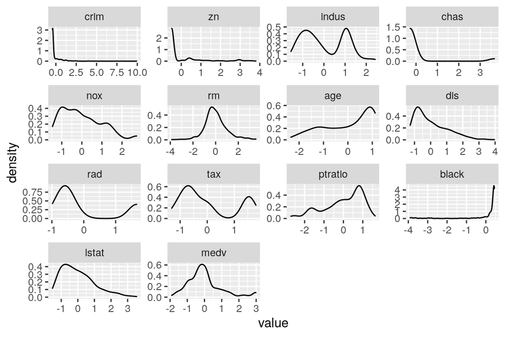

```r
ggplot(longtable, aes(value)) + geom_density() + facet_wrap(~variable, scales="free")
```

In this exercise, we’re trying to ultimately predict the crime rate using Linear Discriminant Analysis (LDA). To do this, we first create a categorical target variable for crime rate by dividing the data. Here we do this by cutting the data into four quantiles.

```r
# create a quantile vector of crim and print it
bins <- quantile(scaled$crim)
bins
```

```
          0%          25%          50%          75%         100%
-0.419366929 -0.410563278 -0.390280295  0.007389247  9.924109610
```

```r
# create a categorical variable 'crime' and take a look using table()
crime <- cut(scaled$crim, breaks = bins, include.lowest = TRUE, label=c("low", "med_low", "med_high", "high"))
table(crime)
```

```
crime
     low  med_low med_high     high
     127      126      126      127
```

```r
# remove original `crim` and add the new `crime` variable to the dataset
# Here I need to explicitly call dplyr::select, as MASS library also has a select function
scaled <- dplyr::select(scaled, -crim)
scaled <- data.frame(scaled, crime)
```

Next up, we’ll have to train and test the LDA model with our data. So, let’s split the data to training and testing datasets using a 80:20 split. Also, the test data shouldn’t contain the true labels so that we don’t confuse our model, but we need that information for verifying our model. So let’s store the labels into another object.

```r
# number of rows in the Boston dataset
n <- nrow(scaled)

# choose randomly 80% of the rows
ind <- sample(n,  size = n * 0.8)

# create train and test sets
train <- scaled[ind,]
test <- scaled[-ind,]  # note the minus!

# save the correct classes from test data
correct_classes_for_test <- test$crime

# remove the crime variable from test data
test <- dplyr::select(test, -crime)
```

## Linear Discriminant Analysis

Now that our data is in a suitable format, let’s get to business. Luckily, fitting the LDA is a one-liner. Here our target is `crime` and explanatory variables are everything else (denoted with `.`). Also, I shamelessly copied the biplot plotting code from Datacamp exercises (because programming it would be too difficult at this point). Let’s see what happens.

```r
lda.fit <- lda(crime ~ ., data = train)
lda.fit  # Just checking the output
```

```
Call:
lda(crime ~ ., data = train)

Prior probabilities of groups:
      low   med_low  med_high      high
0.2549505 0.2400990 0.2599010 0.2450495

Group means:
                 zn      indus        chas        nox         rm        age
low       0.9753697 -0.9434514 -0.08120770 -0.8837233  0.4325390 -0.9381520
med_low  -0.1157120 -0.2855907  0.01179157 -0.5543991 -0.1296850 -0.3048100
med_high -0.3631007  0.1961002  0.25261763  0.3994375  0.1537163  0.3898780
high     -0.4872402  1.0149946 -0.07348562  1.0385550 -0.3794012  0.8013618
                dis        rad        tax     ptratio       black       lstat
low       0.9342664 -0.6785867 -0.7383022 -0.44674754  0.37958778 -0.77846727
med_low   0.3208755 -0.5591880 -0.4598702 -0.04993701  0.31380803 -0.15663318
med_high -0.4035941 -0.4065439 -0.3123179 -0.43168810  0.09591388 -0.05170852
high     -0.8422717  1.6596029  1.5294129  0.80577843 -0.68079981  0.90402871
                medv
low       0.53480421
med_low  -0.02744276
med_high  0.24205894
high     -0.73842724

Coefficients of linear discriminants:
                LD1          LD2         LD3
zn       0.07214555  0.610195519 -0.85295795
indus    0.04785751 -0.409068774  0.13049624
chas    -0.08241604 -0.009705042  0.09797199
nox      0.22690421 -0.714147079 -1.42365374
rm      -0.09277179 -0.062028307 -0.11140387
age      0.26316698 -0.346412935  0.02425944
dis     -0.08409444 -0.147792348 -0.02421958
rad      3.41887302  0.670047867 -0.31331749
tax      0.01133046  0.319706540  0.70765000
ptratio  0.08939538  0.134648187 -0.18848405
black   -0.12840758 -0.012087855  0.07913283
lstat    0.22188192 -0.191386778  0.28940556
medv     0.19374414 -0.370964344 -0.30837420

Proportion of trace:
   LD1    LD2    LD3
0.9470 0.0412 0.0119
```

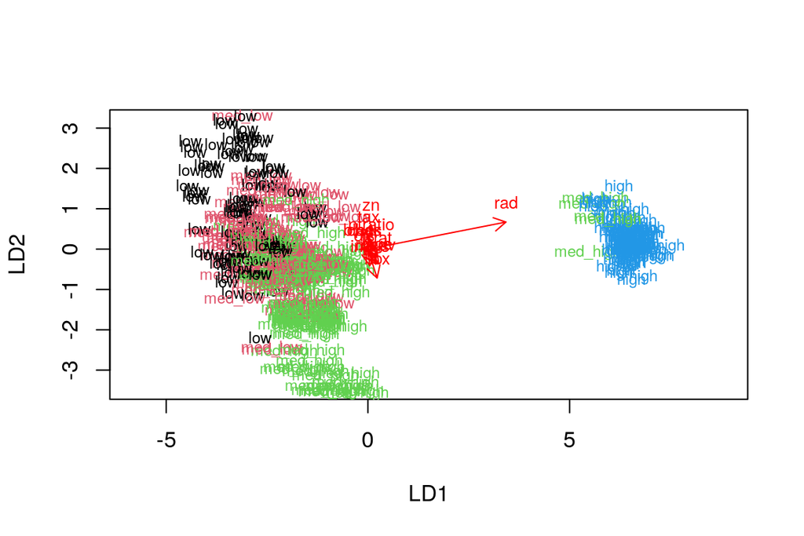

```r
# Function lifted directly from DataCamp exercises
# the function for lda biplot arrows
lda.arrows <- function(x, myscale = 1, arrow_heads = 0.1, color = "red", tex = 0.75, choices = c(1,2)){
  heads <- coef(x)
  arrows(x0 = 0, y0 = 0,
         x1 = myscale * heads[,choices[1]],
         y1 = myscale * heads[,choices[2]], col=color, length = arrow_heads)
  text(myscale * heads[,choices], labels = row.names(heads),
       cex = tex, col=color, pos=3)
}

# target classes as numeric
classes <- as.numeric(train$crime)

# plot the lda results
plot(lda.fit, dimen = 2, col=classes, pch=classes)
lda.arrows(lda.fit, myscale = 1)
```

So, what about our model’s predictions? Predict with test data and cross tabulate the predictions with the actual labels, got it!

```r
# predict classes with test data
lda.pred <- predict(lda.fit, newdata = test)
table(correct = correct_classes_for_test, predicted = lda.pred$class) %>% addmargins
```

```
          predicted
correct    low med_low med_high high Sum
  low       12       7        5    0  24
  med_low    8      17        4    0  29
  med_high   1      11        8    1  21
  high       0       0        1   27  28
  Sum       21      35       18   28 102
```

[output not shown]

## k-means Clustering

Finally, we’ll practice some clustering with the “clustering hello world algorithm”, also known as k-means clustering. Basically this algorithm creates *k* clusters by finding *k* points that minimize the mean distance between the “k-points” and the data points (though it’s not foolproof, the outcome depends on where the initial k-points are). Each data point is assigned to the nearest k-point, which forms the cluster.

Moving on, now that short (and probably a bit unnecessary) introduction is out of the way, I’ll reload the original `Boston` dataset and scale it once again for clustering.

```r
# Reload original Boston dataset
data('Boston')

# Scale the dataset
boston_scaled <- scale(Boston) %>% as.data.frame()
# I won't repeat the summary here, it's the same as shown previously...

# Calculate euclidean distance and show it
dist_eu <- dist(boston_scaled)
summary(dist_eu)
```

```
   Min. 1st Qu.  Median    Mean 3rd Qu.    Max.
 0.1343  3.4625  4.8241  4.9111  6.1863 14.3970
```

```r
# Let's calculate also manhattan distance for good measure
dist_man <- dist(boston_scaled, method="manhattan")
summary(dist_man)
```

```
   Min. 1st Qu.  Median    Mean 3rd Qu.    Max.
 0.2662  8.4832 12.6090 13.5488 17.7568 48.8618
```

Okay, next up is the actual clustering. Let’s start with three k-points and see the result.

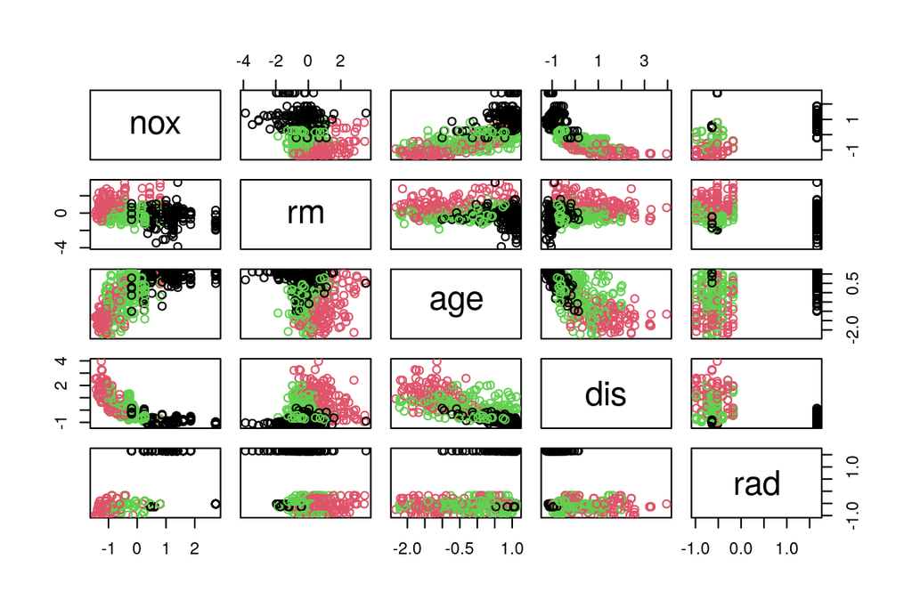

```r
km <-kmeans(boston_scaled, centers = 3)
# Plot a subset of boston_scaled data with clusters colored, just to see how it looks like
pairs(boston_scaled[5:9], col = km$cluster)
```

I don’t know whose idea it was to have black, *red* and *green* as the three first default colors in R… I just hope that these shades of red and green are distinct enough for (red-green) colorblind people are able to tell the difference. And wow, the clusters swap colors when I replot the figure! Yeah, I really have to learn the `ggplot2` library by heart if I’m ever going to use R outside this course. But I digress. Moving on…

Multiple methods for figuring out the optimal value for *k* exist, but here we use a metric called *total of within cluster sum of squares* (WCSS). The optimal number for k is where the WCSS has a *radical* drop! The `kmeans` function returns an object that handily provides the WCSS value in `tot.withinss` component. The DataCamp exercises graciously include an one-liner to calculate WCSS for the data using `k=1...k_max`, so I’m totally going to use that one! Let’s set `k_max` to 10 to limit the iterations a bit and then we’ll look for the optimal value visually - i.e by plotting `WCSS(k)`.

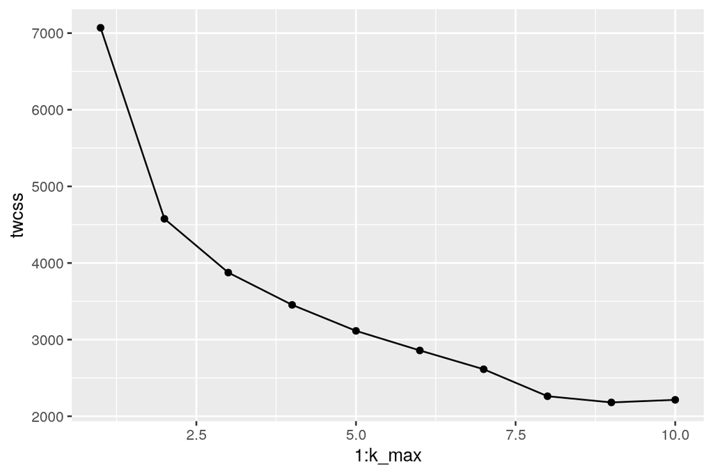

```r
# Maximum number of clusters considered here
k_max <- 10

# This one is also copied from DataCamp...
# calculate the total within sum of squares
twcss <- sapply(1:k_max, function(k){kmeans(boston_scaled, k)$tot.withinss})

# Visualise!
qplot(x = 1:k_max, y = twcss, geom = c('line', 'point'))
```

The most *radical* decrease would be from going `k=1` to `k=2`, so the value 2 seems to be a great candidate. Though the WCSS values drop up to `k=9`, so something like 5 or 7 might be potential candidates. But 2 makes it so that there will be only two colors in the up-coming plots, making them a bit easier to interpret. So I’ll use `k=2`.[^3]

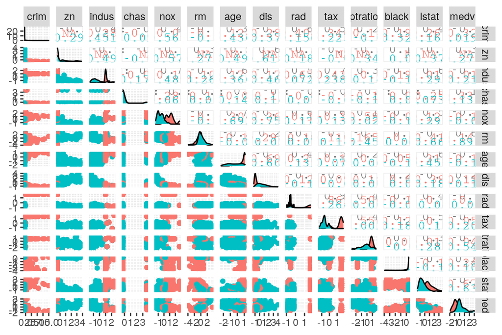

```r
# Re-cluster the data
km <-kmeans(boston_scaled, centers = 2)
#
# plot the Boston dataset with clusters
# This time the full dataset with ggpairs -- it's stil going to be a mess, but it'll be a pretty mess.
ggpairs(boston_scaled, aes(col=as.factor(km$cluster)))
```

```r
# This chunk emits a bunch of "Warning in cor(x, y): the standard deviation is zero" warning messages.
```

Yep, that’s a pretty looking mess. Also that chunk emits a bunch of `Warning in cor(x, y): the standard deviation is zero` warning messages (I’ve omitted those as they’re wasting space). Looks like the correlations for `zn` in the red class are `NA`, so that’s probably where the standard deviation is zero. Anyways, let’s first plot the density plots like before, and then check only a handful of variables with larger pictures.

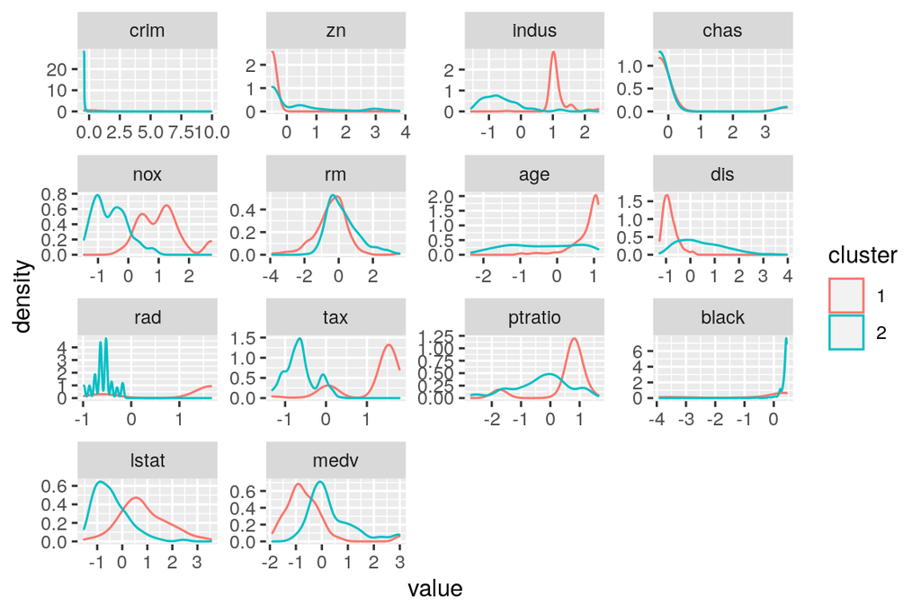

```r
with_colors <- boston_scaled
with_colors$cluster <- as.factor(km$cluster)
longtable <- melt(with_colors)
ggplot(longtable, aes(value, col=cluster)) + geom_density() + facet_wrap(~variable, scales="free")
```

Well, that’s interesting! Some of the variables now show two differing density curves – essentially meaning that there could be a way to separate the data into two different groups. If you recall my pondering from the data exploration, I noted that `indus`, `rad` and `tax` variables show two peaks – well, the two peaks seem to belong into different clusters! However, what I couldn’t see before, was that also `age`, `dis`, `ptratio`, and arguably `lstat` and `medv`, would be a combination of two different (and separable) curves. `nox` being also very separable is not a surprise (in hindsight), when you already know that industrial zones cause more pollution than residential zones (typically).

Let’s pick some variables that look interesting.

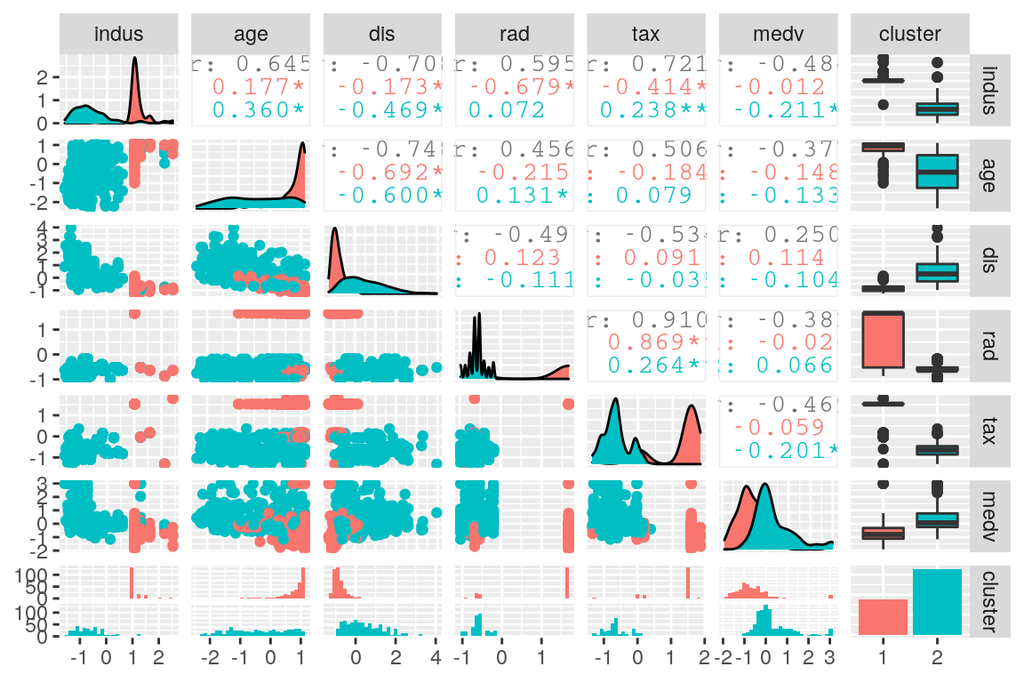

```r
#with_colors <- boston_scaled
#with_colors$cluster <- as.factor(km$cluster)
subset <- dplyr::select(with_colors, c("indus", "age", "dis", "rad", "tax", "medv", "cluster"))
#subset$cluster <- as.factor(subset$cluster)
ggpairs(subset, aes(col=cluster))
```

## Bonus task

Surprise! There are two bonus tasks for this week! There were some also for the last week, but I didn’t do those. But it’s getting a bit late, so this’ll have to be short. The first one is to fit LDA for some number of clusters (>2). I chose 7. For that, the most influential variables seem to be `chas` and `rad`. The second bonus task, well, I can’t manage everything.

```r
# Reload original Boston dataset
data('Boston')

# Scale the dataset
bonus_scaled <- scale(Boston) %>% as.data.frame
summary(bonus_scaled)
```

```
      crim                 zn               indus              chas
 Min.   :-0.419367   Min.   :-0.48724   Min.   :-1.5563   Min.   :-0.2723
 1st Qu.:-0.410563   1st Qu.:-0.48724   1st Qu.:-0.8668   1st Qu.:-0.2723
 Median :-0.390280   Median :-0.48724   Median :-0.2109   Median :-0.2723
 Mean   : 0.000000   Mean   : 0.00000   Mean   : 0.0000   Mean   : 0.0000
 3rd Qu.: 0.007389   3rd Qu.: 0.04872   3rd Qu.: 1.0150   3rd Qu.:-0.2723
 Max.   : 9.924110   Max.   : 3.80047   Max.   : 2.4202   Max.   : 3.6648
      nox                rm               age               dis
 Min.   :-1.4644   Min.   :-3.8764   Min.   :-2.3331   Min.   :-1.2658
 1st Qu.:-0.9121   1st Qu.:-0.5681   1st Qu.:-0.8366   1st Qu.:-0.8049
 Median :-0.1441   Median :-0.1084   Median : 0.3171   Median :-0.2790
 Mean   : 0.0000   Mean   : 0.0000   Mean   : 0.0000   Mean   : 0.0000
 3rd Qu.: 0.5981   3rd Qu.: 0.4823   3rd Qu.: 0.9059   3rd Qu.: 0.6617
 Max.   : 2.7296   Max.   : 3.5515   Max.   : 1.1164   Max.   : 3.9566
      rad               tax             ptratio            black
 Min.   :-0.9819   Min.   :-1.3127   Min.   :-2.7047   Min.   :-3.9033
 1st Qu.:-0.6373   1st Qu.:-0.7668   1st Qu.:-0.4876   1st Qu.: 0.2049
 Median :-0.5225   Median :-0.4642   Median : 0.2746   Median : 0.3808
 Mean   : 0.0000   Mean   : 0.0000   Mean   : 0.0000   Mean   : 0.0000
 3rd Qu.: 1.6596   3rd Qu.: 1.5294   3rd Qu.: 0.8058   3rd Qu.: 0.4332
 Max.   : 1.6596   Max.   : 1.7964   Max.   : 1.6372   Max.   : 0.4406
     lstat              medv
 Min.   :-1.5296   Min.   :-1.9063
 1st Qu.:-0.7986   1st Qu.:-0.5989
 Median :-0.1811   Median :-0.1449
 Mean   : 0.0000   Mean   : 0.0000
 3rd Qu.: 0.6024   3rd Qu.: 0.2683
 Max.   : 3.5453   Max.   : 2.9865
```

```r
# k-means clustering with 7 clusters
km <-kmeans(bonus_scaled, centers = 7)
summary(km)
```

```
             Length Class  Mode
cluster      506    -none- numeric
centers       98    -none- numeric
totss          1    -none- numeric
withinss       7    -none- numeric
tot.withinss   1    -none- numeric
betweenss      1    -none- numeric
size           7    -none- numeric
iter           1    -none- numeric
ifault         1    -none- numeric
```

```r
# Add clusters to dataset
bonus_scaled$cluster <- km$cluster

# LDA fit targetting clusters
lda.fit <- lda(cluster ~ ., data = bonus_scaled)
lda.fit  # Just checking the output
```

```
Call:
lda(cluster ~ ., data = bonus_scaled)

Prior probabilities of groups:
         1          2          3          4          5          6          7
0.09683794 0.09288538 0.06916996 0.15415020 0.17588933 0.34387352 0.06719368

Group means:
        crim         zn      indus       chas        nox         rm         age
1 -0.3774003 -0.1398479 -0.8703728 -0.2723291 -0.2390554  1.5399833  0.07933756
2 -0.2834643 -0.4872402  1.5965043 -0.2723291  1.0453673 -0.6245590  0.94375129
3  1.4802645 -0.4872402  1.0149946 -0.2723291  0.9676887 -0.2969389  0.76560159
4 -0.4126954  1.9952361 -1.1032525 -0.2218534 -1.1552982  0.6080657 -1.40363754
5  0.9722616 -0.4872402  1.0149946 -0.2723291  1.0010692 -0.4790990  0.74608713
6 -0.3884148 -0.3253420 -0.4696145 -0.2723291 -0.4787024 -0.2866326 -0.25638178
7 -0.1985497 -0.2602436  0.2799956  3.6647712  0.3830784  0.2756681  0.37213224
         dis          rad         tax    ptratio       black      lstat
1 -0.2868574 -0.520140581 -0.82627237 -1.0314738  0.35523433 -0.9636997
2 -0.8963217 -0.622669809  0.03772813 -0.2084479 -0.08717824  0.7185475
3 -0.8580043  1.659602895  1.52941294  0.8057784 -3.29705640  1.1699052
4  1.5772490 -0.627024335 -0.57588304 -0.7161406  0.35335146 -0.9028481
5 -0.8009959  1.659602895  1.52941294  0.8057784  0.16590165  0.8119640
6  0.2769540 -0.587168164 -0.59021294  0.1702603  0.30993538 -0.1365045
7 -0.4033382  0.001081444 -0.09756330 -0.3924585  0.17154271 -0.1643525
        medv
1  1.6147330
2 -0.5152915
3 -1.0473739
4  0.6621944
5 -0.6627877
6 -0.1747229
7  0.5733409

Coefficients of linear discriminants:
                 LD1         LD2          LD3         LD4         LD5
crim    -0.032848874 -0.11853833 -0.121992191 -0.04587015  0.02028959
zn      -0.236386535 -0.11164525 -0.892168260  0.07752273 -1.47340439
indus    0.122244436 -0.61676862  1.373115707 -0.29017671 -1.77461828
chas     5.826738406  0.17279307 -0.348402443 -0.10993258 -0.06074649
nox      0.007038657  0.41797220  0.349383719  0.25040677 -0.36306581
```

[output cut: 13 more lines]

```
chas     0.27933856
nox     -0.44219930
rm      -0.56819492
age     -0.24907323
dis      0.14176355
rad     -0.05116781
tax      0.20960416
ptratio  0.32614059
black    0.01111638
lstat   -0.25238312
medv    -0.88020068

Proportion of trace:
   LD1    LD2    LD3    LD4    LD5    LD6
0.5738 0.2535 0.0673 0.0566 0.0353 0.0134
```

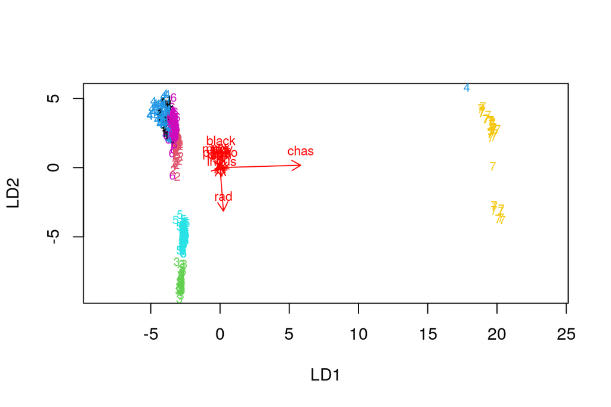

```r
# target classes as numeric
classes <- as.numeric(bonus_scaled$cluster)

# plot the lda results
plot(lda.fit, dimen = 2, col=classes, pch=classes)
lda.arrows(lda.fit, myscale = 1)
```

Back to top.

[^1]: I’m using the `knitr::kable` function here to output prettier tables. It doesn’t affect the data values in any way, it is a purely aesthetic helper function.
[^2]: For factor variables the interpretation is “how the probability changes compared to a baseline class when our estimator moves from baseline to *this* class”.
[^3]: I also got `k=3` as optimal value when I accidentally ran the code without setting seed beforehand. Whoops. Well, like I said, the results of k-means depend on the initial (random) points.